# T-ESP-810

## Load and process data

The objective of this part is to load the dataset and process the data set, in order to optimize the training of the model. We will mainly focus on the training and testing data set.

## Table of Content:

- Summary of data
- Display of training data
- Display of a test Data
- Image processing
  - Properties
  - Pre-treatment result
  - Post treatment result
- Ignoring Noisy data
  - Statistical processing

## Summary of data

```python
from src.project.loader import ChestXray
chestXRAY = ChestXray(debug=False)
chestXRAY.show_dataset_properties()
```

```
Loading Normal train file |██████████████████████████████████████████████████| 100.0% Complete
Loading Pneumonia train file |██████████████████████████████████████████████████| 100.0% Complete
Training : Percentage loss: 0.04 % - Total loaded: 5214 file
Loading Normal test file |██████████████████████████████████████████████████| 100.0% Complete
Loading Pneumonia test file |██████████████████████████████████████████████████| 100.0% Complete
Test : Percentage loss: 0.00 % - Total loaded: 624 file
WARNING: Machine learning disabled
```

|  | Total | Virus | Bacteria | Normal |
| --- | --- | --- | --- | --- |
| Train | 5214 | 1345 | 2530 | 1339 |
| Test | 624 | 148 | 242 | 234 |

## Display of a sample of training data

```python
chestXRAY.show_sample_table_train()
```

|  | filename | label | width | height | extrema greyscale | mean greyscale | median greyscale | extrema | mean | median |
| --- | --- | --- | --- | --- | --- | --- | --- | --- | --- | --- |
| 0 | NORMAL2-IM-0978-0001.jpeg | Normal | 1678 | 1129 | NaN | NaN | NaN | (0, 255) | 114.270781 | 123.0 |
| 1 | NORMAL2-IM-0649-0001.jpeg | Normal | 1518 | 1194 | NaN | NaN | NaN | (0, 255) | 113.524578 | 118.0 |
| 2 | NORMAL2-IM-0995-0001.jpeg | Normal | 1774 | 1318 | NaN | NaN | NaN | (0, 255) | 143.958880 | 159.0 |
| 3 | IM-0435-0001-0001.jpeg | Normal | 1512 | 1209 | NaN | NaN | NaN | (0, 255) | 90.824033 | 94.0 |
| 4 | NORMAL2-IM-0599-0001.jpeg | Normal | 1484 | 1036 | NaN | NaN | NaN | (0, 255) | 125.262195 | 140.0 |
| 5 | NORMAL2-IM-0642-0001.jpeg | Normal | 1546 | 1368 | NaN | NaN | NaN | (0, 255) | 110.586680 | 118.0 |
| 6 | IM-0381-0001.jpeg | Normal | 1744 | 1388 | NaN | NaN | NaN | (0, 255) | 119.077716 | 130.0 |
| 7 | NORMAL2-IM-0775-0001.jpeg | Normal | 1310 | 1136 | NaN | NaN | NaN | (0, 255) | 114.942493 | 127.0 |
| 8 | IM-0650-0001.jpeg | Normal | 1620 | 1159 | NaN | NaN | NaN | (0, 255) | 135.185485 | 154.0 |
| 9 | IM-0640-0001-0001.jpeg | Normal | 1462 | 1140 | NaN | NaN | NaN | (0, 255) | 111.736945 | 119.0 |

## Display of a test Data

```python
chestXRAY.show_sample_table_test()
```

|  | filename | label | width | height | extrema greyscale | mean greyscale | median greyscale | extrema | mean | median |
| --- | --- | --- | --- | --- | --- | --- | --- | --- | --- | --- |
| 0 | IM-0013-0001.jpeg | Normal | 2444 | 2155 | NaN | NaN | NaN | (0, 255) | 136.049440 | 139.0 |
| 1 | IM-0029-0001.jpeg | Normal | 2343 | 2139 | NaN | NaN | NaN | (0, 255) | 149.645986 | 154.0 |
| 2 | NORMAL2-IM-0041-0001.jpeg | Normal | 2187 | 1332 | NaN | NaN | NaN | (0, 255) | 114.862322 | 129.0 |
| 3 | IM-0022-0001.jpeg | Normal | 1300 | 617 | NaN | NaN | NaN | (0, 255) | 86.488534 | 92.0 |
| 4 | NORMAL2-IM-0275-0001.jpeg | Normal | 1748 | 1079 | NaN | NaN | NaN | (0, 255) | 120.291124 | 123.0 |
| 5 | IM-0015-0001.jpeg | Normal | 1803 | 1238 | NaN | NaN | NaN | (0, 255) | 136.620834 | 137.0 |
| 6 | NORMAL2-IM-0317-0001.jpeg | Normal | 1624 | 1187 | NaN | NaN | NaN | (0, 255) | 106.386766 | 110.0 |
| 7 | NORMAL2-IM-0310-0001.jpeg | Normal | 1646 | 1346 | NaN | NaN | NaN | (0, 255) | 128.769531 | 139.0 |
| 8 | NORMAL2-IM-0279-0001.jpeg | Normal | 1376 | 1040 | NaN | NaN | NaN | (0, 255) | 118.826158 | 129.0 |
| 9 | NORMAL2-IM-0300-0001.jpeg | Normal | 1508 | 1260 | NaN | NaN | NaN | (0, 255) | 124.774672 | 130.0 |

## Image processing

### Properties

Starting from the histogram of the following image:

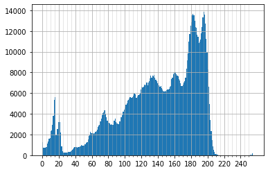

```python
import matplotlib.pyplot as plt
import numpy as np

filename = "person1_bacteria_2.jpeg"
table, origin, treated = chestXRAY.show_pretreatment_image(filename)
table
img, treated = chestXRAY.show_array_image(filename)

fig = plt.figure()
ax = fig.add_subplot(1, 1, 1)
major_ticks = np.arange(0, 255, 20)
minor_ticks = np.arange(0, 255, 5)

ax.set_xticks(major_ticks)
ax.set_xticks(minor_ticks, minor=True)
ax.grid()
ax.grid(which='minor', alpha=0.4)
n, bins, patches = ax.hist(img.flatten(), bins=range(256))
```

There are two areas for improvement:

- Exposure to the image
- Light distribution

Our objective will be to equalize the image so that we can bring out the shades of gray as much as possible.

To do this, we will simply stretch the histogram using the following formula:

Either the intensity:

$[I_{min}, I_{max}] \in [0, 255] $

For x, y the plane coordinates of a pixel, apply the formula:

$$ I' (x, y) = \frac{255\times(I(x,y) - I_{min})}{I_{max} - I_{min}} $$

For the improvement of the contrast, we will try to distribute the gray levels evenly on the axis : $I \in [0, 255] $

We therefore apply the following normal distribution:

$$ I' (x, y) =\lfloor 255. \sum_{i=0}^{I(x,y)} p_i\rfloor $$

In order to facilitate the implementation of these solutions, we used the solutions `autocontrast` and `equalize`of the ImagesOps module of PIL

### Pre-treatment result

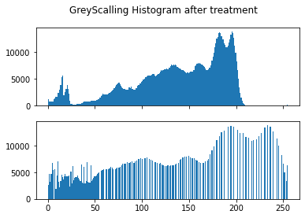

```python
fig, ax = plt.subplots(2, sharex=True, sharey=True)
fig.suptitle('GreyScalling Histogram after treatment')
n, bins, patches = ax[0].hist(img.flatten(), bins=range(256))
n, bins, patches = ax[1].hist(treated.flatten(), bins=range(256))
```

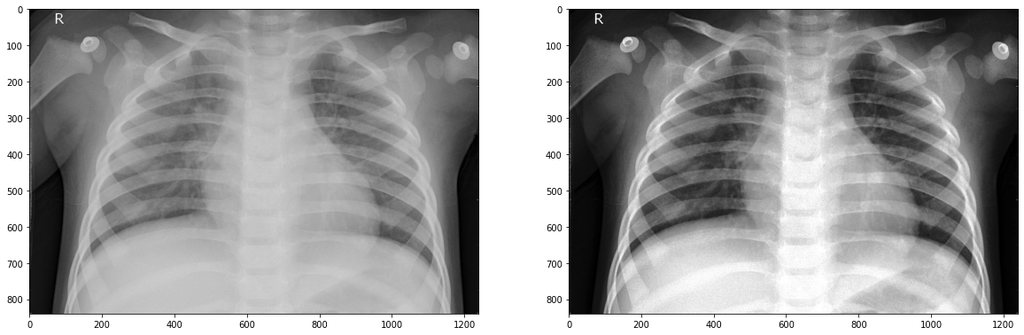

```python
images = (origin, treated)
plt.rcParams["figure.figsize"] = (20, 20)
columns = 2
for i, image in enumerate(images):
    plt.subplot(int(len(images) / columns + 1), columns, i + 1)
    plt.imshow(image,  cmap='gray', vmin=0, vmax=255)
```

### Post treatment result

In order to standardize the size of the image without loss of information, we have chosen to crop the image by the center, For this, we retrieve the median size of the entire dataset as a reference value, then we crop or enlarged equally each image.

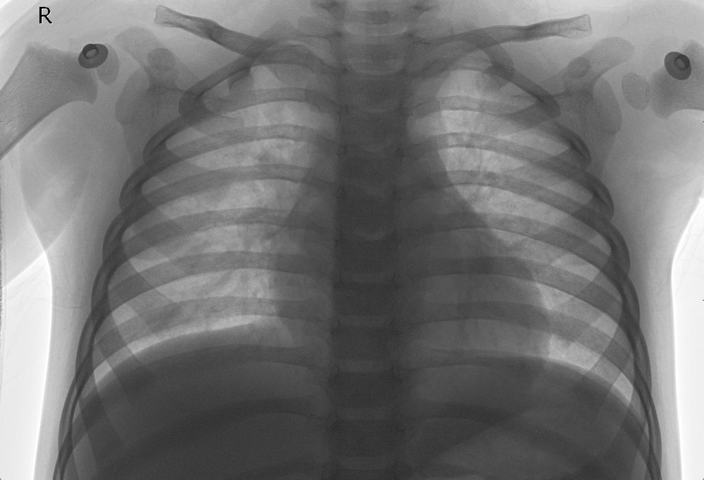

```python
from IPython.display import display
data = chestXRAY.show_post_treatment_image(filename)

display(data.img)
```

## Ignoring Noisy data

A partir de certaine propriété du jeu de données, nous avons tenté de supprimé certain élements pouvant parasiter notre jeu de données

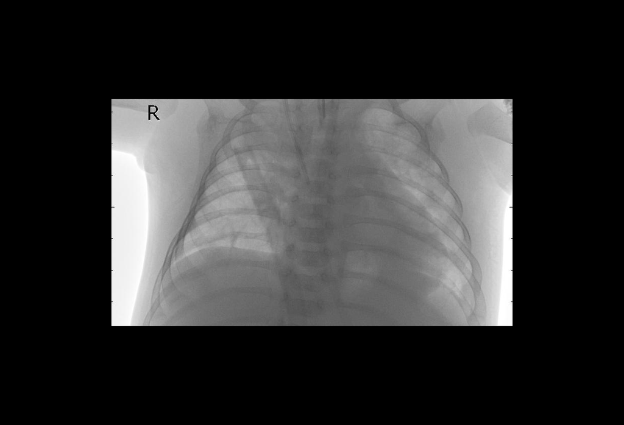

|  | filename | label | width | height | extrema | mean | median |
| --- | --- | --- | --- | --- | --- | --- | --- |
| 0 | person67_bacteria_329.jpeg | Bacteria | 1232 | 840 | (0, 255) | 111.392237 | 122 |

```python
filename = "person67_bacteria_329.jpeg"
data = chestXRAY.show_post_treatment_image(filename)

display(data.img)

data.row
```

### Statistical processing

#### Image size

We have chosen to crop images of different sizes towards the center, in order to limit the loss of information. However, with large disparities in sizes, the loss of information can be quite significant. When we analyze the data set according to the size criteria:

|  | Total | Median Weight | Median Height | Quantile min 5% | Quantile max 95% | Ignore (%) |
| --- | --- | --- | --- | --- | --- | --- |
| 0 | 5214 | 840 | 840 | 367.9 | 1642.0 | 18 |
| 1 | 5214 | 1232 | 1232 | 679.0 | 1906.0 | 7 |

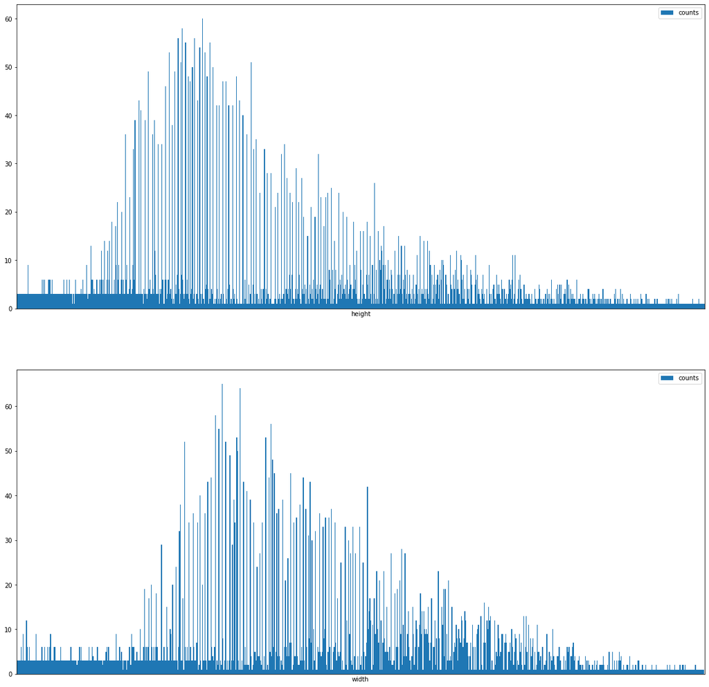

```python
import pandas as pd

dataframe_height = chestXRAY.show_height_total_data()
dataframe_width = chestXRAY.show_width_total_data()
fig, (ax1, ax2) = plt.subplots(2)

dataframe_height.sort_values(by=['height']).groupby(['height']).size().reset_index(name='counts')\
    .plot(x='height', y='counts' ,kind='bar', ax=ax1, xticks=[], width=1.0)

dataframe_width.sort_values(by=['width']).groupby(['width']).size().reset_index(name='counts')\
    .plot(x='width', y='counts' ,kind='bar', ax=ax2, xticks=[],  width=1.0)

table = pd.concat([chestXRAY.show_height_stats(), chestXRAY.show_width_stats()], ignore_index=True)
table
```

This eliminates the extremum data of the curve, in order to limit the parasitic data as much as possible. Arbitrarily, we filter the values beyond outside the 5% and above the 95% of the quartiles.